# Buffered Panel Threshold Regression with bufferedThresholdPanel

Faycal Hamdi, Said Souam, Messaoud Zouikri

2026-05-17

## Overview

The **bufferedThresholdPanel** package implements the Buffered Panel Threshold Data (BTPD) model of Belarbi et al. (2021) for panel data with individual fixed effects. It extends the classical Panel Threshold Regression (PTR) of Hansen (1999) by replacing a single threshold parameter with a *buffer zone* $(r_L, r_U]$. When the threshold variable falls inside this zone, the regime indicator keeps its previous value, producing a hysteresis-driven (path-dependent) transition between regimes.

The package supports:

- **Two-regime models** — one buffer zone, slope vectors $\beta_1$ and $\beta_2$
- **Three-regime models** — two buffer zones, slope vectors $\beta_1$, $\beta_2$, $\beta_3$
- **Classical PTR** of Hansen (1999) as a special case ($r_L = r_U$)
- **Sequential bootstrap tests** for the number of regimes ($F_{1,2}$ and $F_{2,3}$)
- **Parallel bootstrap** confidence intervals
- **Publication-ready tables** in AER and Journal of Econometrics styles

## The Model

### Two-regime BTPD

For a balanced panel $\{Y_{it}, q_{it}, X_{it} : 1 \le i \le N, 1 \le t \le T\}$ with individual fixed effects $\mu_i$:

$$Y_{it} = \mu_i + X_{it}\beta_1
\mathbf{1}(R_{it}=1)
+ X_{it}\beta_2 \mathbf{1}(R_{it}=2) +
\varepsilon_{it}$$

The regime indicator follows the hysteresis rule:

$$R_{it} = \begin{cases}
1 & q_{it} \le r_L \\
R_{i,t-1} & r_L < q_{it} \le r_U \quad \text{(buffer zone:
inherit past regime)} \\
2 & q_{it} > r_U
\end{cases}$$

This path-dependent mechanism — formalised in the time-series context by Li et al. (2015) — means that two units with identical $q_{it}$ values may be assigned to different regimes depending on their history.

### Three-regime BTPD

With two buffer zones $(r_{L,1}, r_{U,1}]$ and $(r_{L,2}, r_{U,2}]$ satisfying $r_{L,1} \le r_{U,1} < r_{L,2} \le r_{U,2}$, the outcome equation becomes:

$$Y_{it} = \mu_i + X_{it}\beta_1
\mathbf{1}(R_{it}=1)
+ X_{it}\beta_2 \mathbf{1}(R_{it}=2)
+ X_{it}\beta_3 \mathbf{1}(R_{it}=3) +
\varepsilon_{it}$$

The regime indicator is determined by five regions of the threshold variable:

| Region | Assignment rule |
| --- | --- |
| $q_{it} \le r_{L,1}$ | Regime 1 (unambiguous) |
| $r_{L,1} < q_{it} \le r_{U,1}$ | Buffer zone 1: stay in 1 if $R_{i,t-1}=1$, else go to 2 |
| $r_{U,1} < q_{it} \le r_{L,2}$ | Regime 2 (unambiguous) |
| $r_{L,2} < q_{it} \le r_{U,2}$ | Buffer zone 2: stay in 2 if $R_{i,t-1} \le 2$, else stay in 3 |
| $q_{it} > r_{U,2}$ | Regime 3 (unambiguous) |

### Estimation

Fixed effects $\mu_i$ are removed by within-group demeaning. For a given set of buffer-zone parameters $\gamma = (r_{L,1}, r_{U,1}, r_{L,2}, r_{U,2})$, the regime indicators are deterministic and the model reduces to OLS applied separately on each regime sub-sample (*concentrated OLS*). The optimal $\hat\gamma$ is the candidate that minimises the concentrated sum of squared residuals over a candidate grid. Heteroskedasticity-robust standard errors (HC0–HC3) are computed via the sandwich estimator.

### Sequential tests

Because the threshold parameter is unidentified under the null hypothesis of linearity, the test statistic does not follow a standard asymptotic distribution — a problem first analysed by Davies (1987). Bootstrap p-values are therefore used throughout.

1. **$F_{1,2}$**: Tests linearity against a two-regime model. Bootstrap draws residuals from the *linear* null.
2. **$F_{2,3}$**: Tests the two-regime model against a three-regime model. Bootstrap draws residuals from the *two-regime* null — the key distinction from $F_{1,2}$ (see Belarbi et al. (2021), Section 2.3).

## Installation

```r
# From CRAN (once published)
install.packages("bufferedThresholdPanel")

# Development version
remotes::install_github("MessaoudZouikri/bufferedThresholdPanel")
```

```r
library(bufferedThresholdPanel)
```

## Quick illustration with simulated data

The examples below use a small simulated panel (N = 30 units, T = 10 periods, 300 observations) so they run quickly. Section Replicating Hamdi et al. (2025) below shows the exact code for the full `panel_data` application.

```r
set.seed(42)
N  <- 30   # cross-sectional units
TT <- 10   # time periods

df_sim <- data.frame(
  id   = rep(seq_len(N), each = TT),
  time = rep(seq_len(TT), N),
  x1   = rnorm(N * TT),
  x2   = rnorm(N * TT),
  q    = rnorm(N * TT)           # threshold variable
)

# True DGP: two regimes separated at q = 0.4
#   Regime 1 (q <= 0.4):  y = 1.5*x1 - 0.5*x2 + e
#   Regime 2 (q >  0.4):  y = -0.5*x1 + 1.0*x2 + e
df_sim$y <- with(df_sim,
  ifelse(q <= 0.4,
         1.5 * x1 - 0.5 * x2,
        -0.5 * x1 + 1.0 * x2) + rnorm(N * TT, 0, 0.5)
)
```

### Estimate a two-regime BTPD model

```r
fit2 <- bptr(
  y ~ x1 + x2,
  data     = df_sim,
  id       = "id",
  time     = "time",
  q        = "q",
  n_thresh = 1,          # 1 threshold → 2 regimes
  buffer   = TRUE,       # BTPD (hysteresis) transitions
  se_type  = "HC3"
)
print(fit2)
```

```
#>
#> --- Buffered Panel Threshold Regression ---
#> Call: bptr(formula = y ~ x1 + x2, data = df_sim, id = "id", time = "time",
#>
#>  Call:     q = "q", n_thresh = 1, buffer = TRUE, se_type = "HC3")
#>
#> Model  : BTPD (buffered)  |  Regimes: 2  |  SE: HC3
#> Panel  : N=30, T=10, NT=300
#> gamma  : 0.3679  0.4212
#> Regime sizes: 208 / 92
#> SSR    : 143.466858  |  Within R2: 0.7805
#>
#>   Regime 1  (n = 208):
#>    Estimate Std.Error  t.value Pr(>|t|)
#> x1   1.4371    0.0415  34.5991        0
#> x2  -0.5174    0.0483 -10.7121        0
#>
#>   Regime 2  (n = 92):
#>    Estimate Std.Error t.value Pr(>|t|)
#> x1  -0.2663    0.0949 -2.8075   0.0054
#> x2   0.9119    0.0863 10.5708   0.0000
```

```r
summary(fit2)
```

```
#>
#> === Buffered Panel Threshold Regression ===
#> Call: bptr(formula = y ~ x1 + x2, data = df_sim, id = "id", time = "time",
#>
#>  Call:     q = "q", n_thresh = 1, buffer = TRUE, se_type = "HC3")
#>
#> Model: BTPD | Regimes: 2 | SE: HC3
#> Panel: N=30, T=10, NT=300
#> Thresholds: 0.3679  0.4212
#> Residual SE: 0.7344 | Within R2: 0.7805 | SSR: 143.4669 | df: 266
#>
#> --- Regime 1  (n = 208) ---
#>    Estimate Std.Error  t.value Pr(>|t|) sig
#> x1   1.4371    0.0415  34.5991        0 ***
#> x2  -0.5174    0.0483 -10.7121        0 ***
#>
#> --- Regime 2  (n = 92) ---
#>    Estimate Std.Error t.value Pr(>|t|) sig
#> x1  -0.2663    0.0949 -2.8075   0.0054 ***
#> x2   0.9119    0.0863 10.5708   0.0000 ***
#>
#> Signif: 0 '***' 0.001 '**' 0.01 '*' 0.05 '.' 0.1 ' ' 1
```

### S3 extractors

```r
# Coefficient matrix (variables × regimes)
round(coef(fit2), 4)
```

```
#>    regime1 regime2
#> x1  1.4371 -0.2663
#> x2 -0.5174  0.9119
```

```r
# Number of regimes in the fitted object
fit2$n_regimes          # 2 for n_thresh=1; 3 for n_thresh=2
```

```
#> [1] 2
```

```r
# Number of observations per regime
fit2$n_obs_regime
```

```
#> [1] 208  92
```

```r
# Within R-squared
round(1 - fit2$ssr / fit2$tss_within, 4)
```

```
#> [1] 0.7805
```

```r
# Threshold / buffer-zone boundaries  [rL, rU]
round(fit2$thresholds, 4)
```

```
#> [1] 0.3679 0.4212
```

```r
# Variance-covariance matrix (block-diagonal by regime)
round(vcov(fit2), 6)
```

```
#>            x1:regime1 x2:regime1 x1:regime2 x2:regime2
#> x1:regime1   0.001725  -0.000216   0.000000   0.000000
#> x2:regime1  -0.000216   0.002333   0.000000   0.000000
#> x1:regime2   0.000000   0.000000   0.008998   0.002243
#> x2:regime2   0.000000   0.000000   0.002243   0.007442
```

```r
# In-sample prediction (identical to fitted values)
head(round(predict(fit2), 4))
```

```
#> [1]  1.2648  0.8507 -0.0541  0.5088 -0.0511 -0.0175
```

```r
# Regime classification matrix (units × periods)
# Each cell shows the regime (1 or 2) assigned to that unit-period pair
regime_table(fit2)[1:5, ]
```

```
#>   1 2 3 4 5 6 7 8 9 10
#> 1 1 2 2 2 1 2 1 2 1  1
#> 2 1 1 2 1 2 2 1 2 1  1
#> 3 2 2 1 1 1 2 1 2 2  1
#> 4 2 2 1 2 2 1 1 2 1  1
#> 5 2 1 1 2 1 1 1 2 1  2
```

### Estimate a three-regime BTPD model

```r
fit3 <- bptr(
  y ~ x1 + x2,
  data        = df_sim,
  id          = "id",
  time        = "time",
  q           = "q",
  n_thresh    = 2,        # 2 thresholds → 3 regimes
  buffer      = TRUE,
  grid_size_3 = 10,       # ⚠ illustration only — use >= 50 for real analyses
  se_type     = "HC3"
)
summary(fit3)
```

```
#>
#> === Buffered Panel Threshold Regression ===
#> Call: bptr(formula = y ~ x1 + x2, data = df_sim, id = "id", time = "time",
#>
#>  Call:     q = "q", n_thresh = 2, buffer = TRUE, grid_size_3 = 10, se_type = "HC3")
#>
#> Model: BTPD | Regimes: 3 | SE: HC3
#> Panel: N=30, T=10, NT=300
#> Thresholds: -0.1739  0.2235  0.4212  0.4212
#> Residual SE: 0.7336 | Within R2: 0.7827 | SSR: 142.0798 | df: 264
#>
#> --- Regime 1  (n = 157) ---
#>    Estimate Std.Error t.value Pr(>|t|) sig
#> x1   1.4511    0.0478 30.3735        0 ***
#> x2  -0.4502    0.0505 -8.9233        0 ***
#>
#> --- Regime 2  (n = 52) ---
#>    Estimate Std.Error t.value Pr(>|t|) sig
#> x1   1.3934    0.0973 14.3248        0 ***
#> x2  -0.6542    0.1092 -5.9933        0 ***
#>
#> --- Regime 3  (n = 91) ---
#>    Estimate Std.Error t.value Pr(>|t|) sig
#> x1  -0.2746    0.0950 -2.8908   0.0042 ***
#> x2   0.9244    0.0863 10.7164   0.0000 ***
#>
#> Signif: 0 '***' 0.001 '**' 0.01 '*' 0.05 '.' 0.1 ' ' 1
```

```r
# Confirm 3 regimes are stored
fit3$n_regimes                               # should be 3
```

```
#> [1] 3
```

```r
cat("Buffer zone 1 : [", round(fit3$thresholds[1], 4),
    ",", round(fit3$thresholds[2], 4), "]\n")
```

```
#> Buffer zone 1 : [ -0.1739 , 0.2235 ]
```

```r
cat("Buffer zone 2 : [", round(fit3$thresholds[3], 4),
    ",", round(fit3$thresholds[4], 4), "]\n")
```

```
#> Buffer zone 2 : [ 0.4212 , 0.4212 ]
```

```r
cat("Regime sizes  :", paste(fit3$n_obs_regime, collapse = " / "), "\n")
```

```
#> Regime sizes  : 157 / 52 / 91
```

### Classical PTR for comparison

```r
fit_ptr <- bptr(
  y ~ x1 + x2,
  data     = df_sim,
  id       = "id",
  time     = "time",
  q        = "q",
  n_thresh = 1,
  buffer   = FALSE        # abrupt transition (Hansen 1999)
)
cat("PTR threshold :", round(fit_ptr$thresholds, 4), "\n")
```

```
#> PTR threshold : 0.4212
```

```r
cat("BTPD zone     : [", round(fit2$thresholds, 4), "]\n")
```

```
#> BTPD zone     : [ 0.3679 0.4212 ]
```

## Tidy output (broom integration)

```r
# Coefficient table with 95% confidence intervals
broom::tidy(fit2, conf.int = TRUE)
```

```
#> # A tibble: 4 × 8
#>   regime term  estimate std.error statistic   p.value conf.low conf.high
#>    <int> <chr>    <dbl>     <dbl>     <dbl>     <dbl>    <dbl>     <dbl>
#> 1      1 x1       1.44     0.0415     34.6  1.82e-100    1.36     1.52
#> 2      1 x2      -0.517    0.0483    -10.7  1.70e- 22   -0.613   -0.422
#> 3      2 x1      -0.266    0.0949     -2.81 5.36e-  3   -0.453   -0.0795
#> 4      2 x2       0.912    0.0863     10.6  4.92e- 22    0.742    1.08
```

```r
# Model-level fit statistics
broom::glance(fit2)
```

```
#> # A tibble: 1 × 9
#>   n_obs n_groups n_thresholds model_type         ssr sigma aic_approx bic_approx
#>   <int>    <int>        <int> <chr>            <dbl> <dbl>      <dbl>      <dbl>
#> 1   300       30            2 2-threshold (bu…  143. 0.734      -209.      -187.
#> # ℹ 1 more variable: r.squared <dbl>
```

```r
# Threshold / buffer-zone estimates
threshold_tidy(fit2)
```

```
#> # A tibble: 2 × 6
#>   threshold_id estimate conf.low conf.high n_regime1 n_regime2
#>          <int>    <dbl>    <dbl>     <dbl>     <int>     <int>
#> 1            1    0.368    0.368     0.368       208        92
#> 2            2    0.421    0.421     0.421       300         0
```

```r
# Add fitted values and regime classification to the data frame
aug <- broom::augment(fit2)
head(aug[, c("id", "time", "q", "y", ".fitted", ".resid", ".regime")])
```

```
#> # A tibble: 6 × 7
#>      id  time      q       y .fitted .resid .regime
#>   <int> <int>  <dbl>   <dbl>   <dbl>  <dbl>   <int>
#> 1     1     1 -0.248  2.53    1.26    0.275       1
#> 2     1     2  0.422  0.918   0.851  -0.923       2
#> 3     1     3  0.988 -0.0943 -0.0541 -1.03        2
#> 4     1     4  0.836  0.202   0.509  -1.30        2
#> 5     1     5 -0.661  1.77   -0.0511  0.830       1
#> 6     1     6  1.56  -1.48   -0.0175 -2.46        2
```

## Diagnostic plots

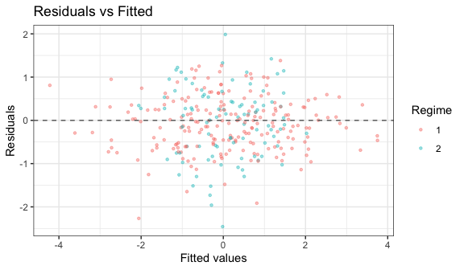

```r
# Residuals vs fitted, coloured by regime
plot(fit2, which = 1)
```

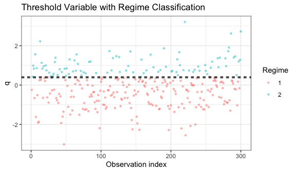

```r
# Threshold variable with buffer-zone boundaries
plot(fit2, which = 2)
```

For fully interactive exploration — upload your own data, run sequential tests, visualise regime dynamics, and export results — launch the built-in Shiny application:

```r
bptr_shiny()
```

## Publication-ready tables

```r
# knitr::kable for R Markdown documents
bptr_kable(fit2, digits = 3)
```

| term | estimate_r1 | std.error_r1 | statistic_r1 | p.value_r1 | estimate_r2 | std.error_r2 | statistic_r2 | p.value_r2 |
| --- | --- | --- | --- | --- | --- | --- | --- | --- |
| x1 | 1.437 | 0.042 | 34.599 | 0 | -0.266 | 0.095 | -2.807 | 0.005 |
| x2 | -0.517 | 0.048 | -10.712 | 0 | 0.912 | 0.086 | 10.571 | 0.000 |

```r
# American Economic Review style (requires gt)
bptr_table(fit2, style = "AER", stars = TRUE,
           title = "Two-Regime BTPD Estimation")

# LaTeX export for inclusion in a paper
bptr_latex(fit2, file = "table_btpd.tex")
```

## Sequential tests (bootstrap — not run in vignette)

The sequential tests require many bootstrap replications and take several minutes on a full panel dataset. The code below shows the exact calls; run them interactively in an R session.

**Three separate functions** implement the sequential strategy of Belarbi et al. (2021), Section 2.3:

- `bptr_test()` — $F_{1,2}$: tests linearity vs a 2-regime model. Returns an object of class `"bptr_test"`.
- `bptr_test_23()` — $F_{2,3}$: tests the 2-regime model vs a 3-regime model. Takes a *fitted* `bptr` object (not a formula) as its first argument, and returns an object of class `"bptr_test23"`.
- `bptr_test_seq()` — runs both tests in sequence, prints step-by-step progress messages to the console via `cat()`, and selects the preferred number of regimes automatically.

Both BTPD (`buffer = TRUE`) and classical PTR (`buffer = FALSE`) tests are supported.

```r
# ── F1,2: linearity vs 2-regime BTPD ──────────────────────────────────────
test12 <- bptr_test(
  y ~ x1 + x2, data = df_sim,
  id = "id", time = "time", q = "q",
  buffer = TRUE, n_boot = 499, seed = 42
)
print(test12)      # class "bptr_test"

# ── F1,2 for classical PTR (buffer = FALSE) ────────────────────────────────
test12_ptr <- bptr_test(
  y ~ x1 + x2, data = df_sim,
  id = "id", time = "time", q = "q",
  buffer = FALSE, n_boot = 499, seed = 42
)
print(test12_ptr)

# ── F2,3: 2-regime vs 3-regime (takes a fitted bptr object as H0) ──────────
# Note: first argument is the fitted 2-regime model, NOT a formula
test23 <- bptr_test_23(fit2, n_boot = 499, grid_size_3 = 50, seed = 42)
print(test23)      # class "bptr_test23" — different print method from test12

# ── Complete sequential procedure (F1,2 → F2,3 → model selection) ──────────
# bptr_test_seq() prints progress via cat() as each step completes
result_seq <- bptr_test_seq(
  y ~ x1 + x2, data = df_sim,
  id = "id", time = "time", q = "q",
  buffer = TRUE, n_boot = 499, alpha = 0.10, seed = 42
)
print(result_seq)
# $n_regimes_selected reports 1, 2, or 3
# $final_model is the recommended fitted bptr object
```

## Bootstrap confidence intervals (not run in vignette)

```r
# Residual bootstrap for the 2-regime BTPD model (parallel on all cores - 1)
boot <- bptr_bootstrap(fit2, n_boot = 499, seed = 42)
print(boot)
# $ci_lower / $ci_upper: named vectors covering gamma1, gamma2,
#   regime1_x1, regime1_x2, regime2_x1, regime2_x2
```

## Replicating Hamdi et al. (2025)

The `panel_data` dataset ships with the package: 92 countries, 2002–2016, 1 380 observations, no missing values. The code below replicates the analysis of Hamdi et al. (2025). Run it interactively — the sequential test and bootstrap steps take several minutes.

```r
data(panel_data)

cat("Countries :", length(unique(panel_data$country)), "\n")
```

```
#> Countries : 92
```

```r
cat("Years     :", min(panel_data$year), "–", max(panel_data$year), "\n")
```

```
#> Years     : 2002 – 2016
```

```r
cat("Obs       :", nrow(panel_data), "\n")
```

```
#> Obs       : 1380
```

```r
cat("Columns   :", ncol(panel_data), "\n")
```

```
#> Columns   : 14
```

```r
# Both threshold variables and the dependent variable
summary(panel_data[, c("growthRate", "oilRentGDP", "rle", "eci")])
```

```
#>    growthRate          oilRentGDP            rle              eci
#>  Min.   :-0.376025   Min.   : 0.00000   Min.   :0.0000   Min.   :0.0000
#>  1st Qu.: 0.008653   1st Qu.: 0.00000   1st Qu.:0.2811   1st Qu.:0.3765
#>  Median : 0.025416   Median : 0.04667   Median :0.4489   Median :0.5232
#>  Mean   : 0.024074   Mean   : 3.35954   Mean   :0.4999   Mean   :0.5335
#>  3rd Qu.: 0.044874   3rd Qu.: 1.32265   3rd Qu.:0.7103   3rd Qu.:0.6905
#>  Max.   : 0.218143   Max.   :59.23777   Max.   :1.0000   Max.   :1.0000
```

### Estimation (runs quickly)

```r
# Model I: oilRentGDP as threshold, rle as predictor
fit2_I <- bptr(
  growthRate ~ rle + eci + initialGDP + fdiGDP + capFormGDP +
               inflation + popGrowth + indVAGDP + tradeOpenness,
  data      = panel_data,
  id        = "countryId",
  time      = "year",
  q         = "oilRentGDP",
  n_thresh  = 1,
  buffer    = TRUE,
  grid_size = 50,    # cap grid for vignette speed
  se_type   = "HC3"
)
print(fit2_I)
```

```
#>
#> --- Buffered Panel Threshold Regression ---
#> Call: bptr(formula = growthRate ~ rle + eci + initialGDP + fdiGDP +
#>
#>  Call:     capFormGDP + inflation + popGrowth + indVAGDP + tradeOpenness,
#>
#>  Call:     data = panel_data, id = "countryId", time = "year", q = "oilRentGDP",
#>
#>  Call:     n_thresh = 1, buffer = TRUE, grid_size = 50, se_type = "HC3")
#>
#> Model  : BTPD (buffered)  |  Regimes: 2  |  SE: HC3
#> Panel  : N=92, T=15, NT=1380
#> gamma  : 0  2e-04
#> Regime sizes: 444 / 936
#> SSR    : 1.238363  |  Within R2: 0.2142
#>
#>   Regime 1  (n = 444):
#>               Estimate Std.Error t.value Pr(>|t|)
#> rle             0.0473    0.1066  0.4440   0.6571
#> eci            -0.1992    0.0767 -2.5965   0.0095
#> initialGDP     -0.0678    0.0180 -3.7623   0.0002
#> fdiGDP          0.0001    0.0003  0.2631   0.7925
#> capFormGDP      0.0027    0.0006  4.2575   0.0000
#> inflation       0.0000    0.0005 -0.0457   0.9636
#> popGrowth       0.0014    0.0080  0.1749   0.8612
#> indVAGDP        0.0000    0.0015 -0.0116   0.9907
#> tradeOpenness   0.0003    0.0001  2.2872   0.0223
#>
#>   Regime 2  (n = 936):
#>               Estimate Std.Error t.value Pr(>|t|)
#> rle             0.0256    0.0267  0.9595   0.3375
#> eci             0.0503    0.0264  1.9034   0.0572
#> initialGDP     -0.0780    0.0093 -8.4159   0.0000
#> fdiGDP          0.0006    0.0003  1.7876   0.0741
#> capFormGDP      0.0015    0.0004  4.3175   0.0000
#> inflation       0.0002    0.0001  1.3991   0.1620
#> popGrowth      -0.0088    0.0022 -4.0481   0.0001
#> indVAGDP        0.0023    0.0007  3.1440   0.0017
#> tradeOpenness   0.0004    0.0001  3.9713   0.0001
```

```r
# Model II: rle as threshold, oilRentGDP as predictor
fit2_II <- bptr(
  growthRate ~ oilRentGDP + eci + initialGDP + fdiGDP + capFormGDP +
               inflation + popGrowth + indVAGDP + tradeOpenness,
  data      = panel_data,
  id        = "countryId",
  time      = "year",
  q         = "rle",
  n_thresh  = 1,
  buffer    = TRUE,
  grid_size = 50,    # cap grid for vignette speed
  se_type   = "HC3"
)
print(fit2_II)
```

```
#>
#> --- Buffered Panel Threshold Regression ---
#> Call: bptr(formula = growthRate ~ oilRentGDP + eci + initialGDP + fdiGDP +
#>
#>  Call:     capFormGDP + inflation + popGrowth + indVAGDP + tradeOpenness,
#>
#>  Call:     data = panel_data, id = "countryId", time = "year", q = "rle",
#>
#>  Call:     n_thresh = 1, buffer = TRUE, grid_size = 50, se_type = "HC3")
#>
#> Model  : BTPD (buffered)  |  Regimes: 2  |  SE: HC3
#> Panel  : N=92, T=15, NT=1380
#> gamma  : 0.234  0.234
#> Regime sizes: 208 / 1172
#> SSR    : 1.202479  |  Within R2: 0.2370
#>
#>   Regime 1  (n = 208):
#>               Estimate Std.Error t.value Pr(>|t|)
#> oilRentGDP      0.0009    0.0008  1.1591   0.2466
#> eci            -0.1869    0.1002 -1.8641   0.0625
#> initialGDP     -0.0921    0.0266 -3.4655   0.0005
#> fdiGDP         -0.0005    0.0007 -0.7898   0.4298
#> capFormGDP      0.0017    0.0010  1.5913   0.1118
#> inflation       0.0000    0.0003 -0.1635   0.8701
#> popGrowth       0.0316    0.0252  1.2505   0.2113
#> indVAGDP        0.0006    0.0031  0.2023   0.8397
#> tradeOpenness   0.0009    0.0004  2.1176   0.0344
#>
#>   Regime 2  (n = 1172):
#>               Estimate Std.Error t.value Pr(>|t|)
#> oilRentGDP      0.0008    0.0005  1.5364   0.1247
#> eci             0.0151    0.0268  0.5629   0.5736
#> initialGDP     -0.0636    0.0084 -7.5915   0.0000
#> fdiGDP          0.0003    0.0004  0.7361   0.4618
#> capFormGDP      0.0021    0.0003  6.3705   0.0000
#> inflation       0.0000    0.0002 -0.0557   0.9556
#> popGrowth      -0.0098    0.0019 -5.0345   0.0000
#> indVAGDP        0.0025    0.0007  3.3722   0.0008
#> tradeOpenness   0.0002    0.0001  2.6732   0.0076
```

### Sequential test and 3-regime model (slow — run interactively)

```r
# Model I: oilRentGDP as threshold, rle as predictor
seq_I <- bptr_test_seq(
  growthRate ~ rle + eci + initialGDP + fdiGDP + capFormGDP +
               inflation + popGrowth + indVAGDP + tradeOpenness,
  data        = panel_data,
  id          = "countryId",
  time        = "year",
  q           = "oilRentGDP",
  buffer      = TRUE,
  n_boot      = 499,
  grid_size_3 = 50,
  alpha       = 0.10,
  seed        = 2025
)
print(seq_I)

# Model II: rle as threshold, oilRentGDP as predictor
seq_II <- bptr_test_seq(
  growthRate ~ oilRentGDP + eci + initialGDP + fdiGDP + capFormGDP +
               inflation + popGrowth + indVAGDP + tradeOpenness,
  data        = panel_data,
  id          = "countryId",
  time        = "year",
  q           = "rle",
  buffer      = TRUE,
  n_boot      = 499,
  grid_size_3 = 50,
  alpha       = 0.10,
  seed        = 2025
)
print(seq_II)

# Fine-grid three-regime estimation for the selected model(s)
fit3_I <- bptr(
  growthRate ~ rle + eci + initialGDP + fdiGDP + capFormGDP +
               inflation + popGrowth + indVAGDP + tradeOpenness,
  data        = panel_data,
  id          = "countryId", time = "year",
  q           = "oilRentGDP",
  n_thresh    = 2, buffer = TRUE, grid_size_3 = 80, se_type = "HC3"
)
summary(fit3_I)

fit3_II <- bptr(
  growthRate ~ oilRentGDP + eci + initialGDP + fdiGDP + capFormGDP +
               inflation + popGrowth + indVAGDP + tradeOpenness,
  data        = panel_data,
  id          = "countryId", time = "year",
  q           = "rle",
  n_thresh    = 2, buffer = TRUE, grid_size_3 = 80, se_type = "HC3"
)
summary(fit3_II)

# Bootstrap confidence intervals
boot_I  <- bptr_bootstrap(fit2_I,  n_boot = 499, seed = 2025)
boot_II <- bptr_bootstrap(fit2_II, n_boot = 499, seed = 2025)
print(boot_I); print(boot_II)
```

## Grid resolution guide

| Model | Buffer? | Grid parameter | SSR evaluations (approx.) |
| --- | --- | --- | --- |
| 2-regime PTR | No | `grid_size = 300` | 300 |
| 2-regime BTPD | Yes | `grid_size = 300` | 45 000 |
| 3-regime PTR | No | `grid_size = 300` | 45 000 |
| 3-regime BTPD | Yes | `grid_size_3 = 50` | 260 000 |

Use smaller values during exploration (`grid_size = 100`, `grid_size_3 = 20`) and increase to 300 / 50 (or higher) for final published results.

## Citation

If you use this package in published research, please cite the package and the two underlying methodology papers. Running the following command inside R will display the full citation details:

```r
citation("bufferedThresholdPanel")
```

The three entries returned are:

1. **The R package itself** — Hamdi, Souam, and Zouikri (2025), v0.1.0
2. **The empirical application** — Hamdi, Souam, and Zouikri (2025, *The World Economy*) — the paper that introduced the two-model framework (Model I: `oilRentGDP` as threshold; Model II: `rle` as threshold) and the `panel_data` dataset included with this package
3. **The methodology paper** — Belarbi, Hamdi, Khalfi, and Souam (2021, *Economic Modelling*) — the paper that formalised the BTPD model and the sequential $F_{1,2}$ / $F_{2,3}$ bootstrap tests

## References

Belarbi, Yacine, Fayçal Hamdi, Abderaouf Khalfi, and Saïd Souam. 2021. “Growth, Institutions and Oil Dependence: A Buffered Threshold Panel Approach.” *Economic Modelling* 99: 105477. https://doi.org/10.1016/j.econmod.2021.02.018.

Davies, Robert B. 1987. “Hypothesis Testing When a Nuisance Parameter Is Present Only Under the Alternative.” *Biometrika* 74 (1): 33–43. https://doi.org/10.1093/biomet/74.1.33.

Hamdi, Fayçal, Saïd Souam, and Messaoud Zouikri. 2025. “The Heterogeneous Effect of Economic Complexity on Growth and Human Development: New Empirical Evidence Using Buffered Panel Threshold Regression.” *The World Economy* 48: 2561–92. https://doi.org/10.1111/twec.70023.

Hansen, Bruce E. 1999. “Threshold Effects in Non-Dynamic Panels: Estimation, Testing, and Inference.” *Journal of Econometrics* 93 (2): 345–68. https://doi.org/10.1016/S0304-4076(99)00025-1.

Li, Guodong, Bo Guan, Wai Keung Li, and Philip L. H. Yu. 2015. “Hysteretic Autoregressive Time Series Models.” *Biometrika* 102 (3): 717–23. https://doi.org/10.1093/biomet/asv017.